# **Química del agua**

Luisa Fernanda Goméz Chabala

2020-07-02

# Unidad Uno

## PROPIEDADES QUÍMICAS DEL AGUA

Siempre hemos escuchado que el agua es vida, y realmente es una frase que no se aleja de la realidad. Si tuviéramos la capacidad de salir al espacio y observar la tierra, podríamos notar que la mayor parte de nuestro planeta es agua. Un 97% son los océanos y el 3% restante, está compuesto por rìos, nieve, glaciares, lagunas, lagos, aguas subterráneas, etc. Todos los recursos hídricos nombrados anteriormente forman la hidrósfera.

Molecularmente, el agua está formando por dos átomos de hidrógeno y uno de oxígeno (fórmula molecular H2O), gracias a la presencia del par de electrones libres sobre el átomo de oxígeno, le confiere a la molécula de agua una geometría angular que a su vez se puede asociar con el su momento dipolar diferente a cero, característica presente en las moléculas polares.

A continuación, en la tabla 1, se listan las principales características de la molécula de agua:

### Tabla1

Propiedades químicas del agua

| CARACTERISTICAS | VALORES |
| --- | --- |
| Geometría | Angular |
| Hibridación | $sp^3$ |
| Ángulo de enlace | $105.4^{\circ}$ |
| Momento dipolar | 1.884 debye |
| Polaridad | Polar |
| Fuerzas intermoleculares | Dipolo-dipolo; Puentes de hidrógeno |

Respecto a las propiedades físicas, tenemos el punto de fusión, evaporación, color y densidad, son las más conocidas.

Una de las propiedades físicas del agua que puede variar con la temperatura es la densidad. Cuando ponemos un cubo de hielo en un vaso con agua, el hielo flota por tener menor densidad que el agua. Esta disminución se debe al aumento de volumen en la rede cristalina del hielo.

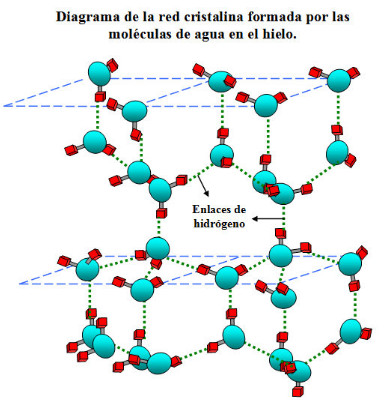

Estructura del hielo y formación de los puentes de hidrógeno [Imagen tomada de (n.d.-a)]

Cuando el agua se congelada, las moléculas tetraédricas tienden abrirse, permitiendo que cada átomo de oxígeno interactúe con cuatro moléculas de agua a partir de los puentes de hidrógeno, dando como el patrón que se muestra en la imagen 1.

Al aumentar la temperatura hasta 4°C el hielo pierde su patrón, disminuyendo los puentes de hidrógeno y el volumen en el agua líquida, aumentando la densidad.

### Modelo “ Flickering cluster” en el agua líquida

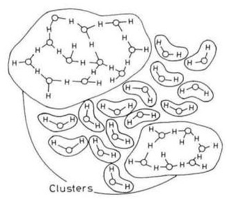

Modelo “ Flickering cluster” en el agua líquida [Imagen tomada de (n.d.-b)]

## AUTOPROTÓLISIS

$$\begin{equation}
H2O+H2O \rightleftharpoons H3O^{+}+^{-}OH
\end{equation}$$

La autoprotólisis del agua a temperatura ambiente es bajo, por esta razón las concentraciones de los iones hidronio e hidroxilo llegan a ser muy baja alcanzando un valor aproximado a $1\times 10^{-7} M$.

La reacción anterior es un equilibrio químico, lo que tiene asociado una constante que se conoce como $Kw$

Como la concentración del agua es muy diluida, se puede aproximar la concentración a una constante, $Kw= [H2O]^2*K$

Donde el valor de $Kw= 1.00\times 10^{-14}$, a una temperatura de $25^{\circ} C$.

# Bibliografía

(n.d.-a). Retrieved from http://delnutrientealadieta.com/2016/01/23/el-agua/8/

(n.d.-b). Retrieved from https://www.ukessays.com/essays/chemistry/structure-water-dynamic-hydrogen-bond-6136.php